# Model 4: Cross-Cohort TV-Sleep Comparisons

# About this script

**Preregistered analysis (main text; RQ4).** Joint models testing whether the within- and between-person associations between TV viewing and sleep differ across MIDUS samples: Model 4a compares MIDUS 2 and MIDUS 3 (the same cohort at a later wave); Model 4b compares MIDUS 2 and MIDUS Refresher 1 (a different cohort). Each is Model 2b plus wave/cohort intercepts and wave/cohort-specific TV effects, with the random intercept and random scale carried forward from Model 1b. Run the three structuring scripts first.

Iterations were increased to meet the prereg ESS criterion (> 1000): Model 4a uses 16000 iterations (4000 warmup); Model 4b uses 8000 (4000 warmup).

# Packages, data, and helper functions

```r
library(dplyr)
library(brms)
```

```r
M2_sample <- readRDS("../midus_2/M2_analysis_data_fulltime_standard.rds")
M3_sample <- readRDS("../midus_3/M3_analysis_data_fulltime_standard.rds")
MR_sample <- readRDS("../midus_refresher/MR_analysis_data_fulltime_standard.rds")

model_output_dir <- "model_fits_cross_wave"
dir.create(model_output_dir, showWarnings = FALSE, recursive = TRUE)

# Prereg convergence criteria: R-hat < 1.01, bulk and tail ESS > 1000,
# and 0 divergent transitions (population-level, SD, and correlation
# parameters)
check_convergence <- function(fit) {
  draws_summary <- posterior::summarise_draws(
    as_draws_df(fit, variable = "^(b_|sd_|cor_|sigma$)", regex = TRUE),
    "rhat", "ess_bulk", "ess_tail"
  )

  tibble(
    max_rhat = max(draws_summary$rhat, na.rm = TRUE),
    min_bulk_ess = min(draws_summary$ess_bulk, na.rm = TRUE),
    min_tail_ess = min(draws_summary$ess_tail, na.rm = TRUE),
    divergent = sum(nuts_params(fit, pars = "divergent__")$Value)
  ) %>%
    mutate(
      meets_prereg = max_rhat < 1.01 & min_bulk_ess > 1000 &
        min_tail_ess > 1000 & divergent == 0
    )
}

# Prereg assumption check: Q-Q plot of level-1 residuals
check_residual_normality <- function(fit, label) {
  resid_est <- residuals(
    fit,
    method = "posterior_predict"
  )[, "Estimate"]

  qqnorm(
    resid_est,
    main = paste0(label, ": Level-1 residual Q-Q plot")
  )

  qqline(resid_est)
}

# All samples are already restricted to full-time, standard shift
stopifnot(
  all(M2_sample$is_fulltime == 1), all(M2_sample$is_standard_shift == 1),
  all(M3_sample$is_fulltime == 1), all(M3_sample$is_standard_shift == 1),
  all(MR_sample$is_fulltime == 1), all(MR_sample$is_standard_shift == 1)
)
```

# Preparing each wave’s sample

Within each wave, as in the single-wave models: age is mean-centered at the participant level, TV is person-mean centered (`tv_within`), and each person’s TV mean is grand-mean centered across that wave’s participants (`tv_person_mean`).

```r
prepare_wave_sample <- function(data) {

  age_mean <- data %>%
    distinct(id, age) %>%
    summarise(m = mean(age, na.rm = TRUE)) %>%
    pull(m)

  data <- data %>%
    mutate(
      age_centered = age - age_mean
    ) %>%
    group_by(id) %>%
    mutate(
      tv_person_mean_raw = mean(tv_duration_minutes, na.rm = TRUE),
      tv_within = tv_duration_minutes - tv_person_mean_raw
    ) %>%
    ungroup()

  # Equally weighted mean of participants' TV means
  tv_grand_mean <- data %>%
    distinct(id, tv_person_mean_raw) %>%
    summarise(m = mean(tv_person_mean_raw, na.rm = TRUE)) %>%
    pull(m)

  data %>%
    mutate(tv_person_mean = tv_person_mean_raw - tv_grand_mean)
}

M2_prepared <- prepare_wave_sample(M2_sample)
M3_prepared <- prepare_wave_sample(M3_sample)
MR_prepared <- prepare_wave_sample(MR_sample)

# QC: within-person deviations average ~0 per person; centered person
# means average ~0 per wave
bind_rows(
  M2 = M2_prepared, M3 = M3_prepared, MR = MR_prepared,
  .id = "wave"
) %>%
  group_by(wave, id) %>%
  summarise(
    mean_tv_within = mean(tv_within, na.rm = TRUE),
    tv_person_mean = first(tv_person_mean),
    .groups = "drop"
  ) %>%
  group_by(wave) %>%
  summarise(
    max_abs_mean_tv_within = max(abs(mean_tv_within), na.rm = TRUE),
    mean_tv_person_mean = mean(tv_person_mean, na.rm = TRUE)
  )
```

```
## # A tibble: 3 × 3
##   wave  max_abs_mean_tv_within mean_tv_person_mean
##   <chr>                  <dbl>               <dbl>
## 1 M2                  2.44e-14            5.17e-15
## 2 M3                  1.62e-14           -4.28e-16
## 3 MR                  2.44e-14            1.91e-15
```

# Model 4a: MIDUS 2 and MIDUS 3

The same participants can appear in both waves, so each person’s wave-specific random intercepts and scales are allowed to correlate.

```r
data_4a <- bind_rows(
  M2_prepared %>% mutate(wave = "MIDUS2"),
  M3_prepared %>% mutate(wave = "MIDUS3")
)

data_4a$wave <- factor(
  data_4a$wave,
  levels = c("MIDUS2", "MIDUS3")
)

cat(
  "Model 4a data:\n",
  "MIDUS 2 participants:", n_distinct(data_4a$id[data_4a$wave == "MIDUS2"]), "\n",
  "MIDUS 3 participants:", n_distinct(data_4a$id[data_4a$wave == "MIDUS3"]), "\n"
)
```

```
## Model 4a data:
##  MIDUS 2 participants: 656
##  MIDUS 3 participants: 279
```

```r
bf_model_4a <- bf(
  sleep_next_night_minutes ~
    0 + wave +
    weekend +
    age_centered +
    sex +
    wave:tv_within +
    wave:tv_person_mean +
    (0 + wave | c | id),

  sigma ~
    0 + wave +
    (0 + wave | c | id)
)

fit_4a <- brm(
  bf_model_4a,
  data = data_4a,
  family = gaussian(),
  chains = 4,
  # Iterations increased per prereg (ESS criterion)
  iter = 16000,
  warmup = 4000,
  seed = 2026,
  save_pars = save_pars(all = TRUE),
  file = file.path(model_output_dir, "model_4a_m2_m3"),
  file_refit = "never"
)

summary(fit_4a, prob = 0.9)
```

```
##  Family: gaussian
##   Links: mu = identity; sigma = log
## Formula: sleep_next_night_minutes ~ 0 + wave + weekend + age_centered + sex + wave:tv_within + wave:tv_person_mean + (0 + wave | c | id)
##          sigma ~ 0 + wave + (0 + wave | c | id)
##    Data: data_4a (Number of observations: 6098)
##   Draws: 4 chains, each with iter = 16000; warmup = 4000; thin = 1;
##          total post-warmup draws = 48000
##
## Multilevel Hyperparameters:
## ~id (Number of levels: 766)
##                                        Estimate Est.Error l-90% CI u-90% CI
## sd(waveMIDUS2)                            41.11      1.56    38.58    43.71
## sd(waveMIDUS3)                            45.22      2.41    41.39    49.27
## sd(sigma_waveMIDUS2)                       0.49      0.02     0.46     0.53
## sd(sigma_waveMIDUS3)                       0.49      0.03     0.44     0.54
## cor(waveMIDUS2,waveMIDUS3)                 0.74      0.06     0.64     0.83
## cor(waveMIDUS2,sigma_waveMIDUS2)          -0.31      0.06    -0.39    -0.21
## cor(waveMIDUS3,sigma_waveMIDUS2)          -0.32      0.08    -0.46    -0.18
## cor(waveMIDUS2,sigma_waveMIDUS3)          -0.20      0.10    -0.36    -0.02
## cor(waveMIDUS3,sigma_waveMIDUS3)          -0.23      0.08    -0.36    -0.09
## cor(sigma_waveMIDUS2,sigma_waveMIDUS3)     0.25      0.10     0.07     0.41
##                                        Rhat Bulk_ESS Tail_ESS
## sd(waveMIDUS2)                         1.00    10897    20898
## sd(waveMIDUS3)                         1.00    15361    25858
## sd(sigma_waveMIDUS2)                   1.00    13891    26969
## sd(sigma_waveMIDUS3)                   1.00    16169    27346
## cor(waveMIDUS2,waveMIDUS3)             1.00     8255    15875
## cor(waveMIDUS2,sigma_waveMIDUS2)       1.00     7814    17633
## cor(waveMIDUS3,sigma_waveMIDUS2)       1.00     1989     4402
## cor(waveMIDUS2,sigma_waveMIDUS3)       1.00     4959    12283
## cor(waveMIDUS3,sigma_waveMIDUS3)       1.00    11421    22016
## cor(sigma_waveMIDUS2,sigma_waveMIDUS3) 1.00     5827    12028
##
## Regression Coefficients:
##                           Estimate Est.Error l-90% CI u-90% CI Rhat Bulk_ESS
## waveMIDUS2                  418.62      2.51   414.49   422.77 1.00     7545
## waveMIDUS3                  416.58      3.32   411.11   422.01 1.00    11497
## weekend                      11.32      1.41     8.99    13.63 1.00    34146
## age_centered                 -0.13      0.21    -0.47     0.21 1.00     9641
## sex                           9.43      3.38     3.84    14.95 1.00     8431
## waveMIDUS2:tv_within         -0.02      0.01    -0.04     0.01 1.00    49083
## waveMIDUS3:tv_within         -0.01      0.02    -0.04     0.03 1.00    47787
## waveMIDUS2:tv_person_mean     0.04      0.03    -0.01     0.09 1.00     9615
## waveMIDUS3:tv_person_mean    -0.03      0.04    -0.10     0.05 1.00    19632
## sigma_waveMIDUS2              3.95      0.02     3.92     3.99 1.00    15897
## sigma_waveMIDUS3              3.92      0.03     3.86     3.97 1.00    16470
##                           Tail_ESS
## waveMIDUS2                   14477
## waveMIDUS3                   22132
## weekend                      35140
## age_centered                 18036
## sex                          15940
## waveMIDUS2:tv_within         38150
## waveMIDUS3:tv_within         37597
## waveMIDUS2:tv_person_mean    18461
## waveMIDUS3:tv_person_mean    28303
## sigma_waveMIDUS2             25450
## sigma_waveMIDUS3             24353
##
## Draws were sampled using sampling(NUTS). For each parameter, Bulk_ESS
## and Tail_ESS are effective sample size measures, and Rhat is the potential
## scale reduction factor on split chains (at convergence, Rhat = 1).
```

```r
fixef(fit_4a, probs = c(0.05, 0.95))
```

```
##                                Estimate  Est.Error           Q5          Q95
## waveMIDUS2                418.616429445 2.50978178 414.49425357 4.227664e+02
## waveMIDUS3                416.580132601 3.31632419 411.11253898 4.220054e+02
## weekend                    11.315017207 1.41023554   8.99354802 1.363246e+01
## age_centered               -0.132296574 0.20576327  -0.46872999 2.098343e-01
## sex                         9.426283143 3.37669052   3.84168867 1.494561e+01
## waveMIDUS2:tv_within       -0.015307636 0.01303973  -0.03660083 6.147322e-03
## waveMIDUS3:tv_within       -0.006581678 0.01990119  -0.03939360 2.607272e-02
## waveMIDUS2:tv_person_mean   0.038884739 0.03102643  -0.01196770 9.001274e-02
## waveMIDUS3:tv_person_mean  -0.025260091 0.04406875  -0.09791756 4.693453e-02
## sigma_waveMIDUS2            3.954009897 0.02335520   3.91553284 3.992408e+00
## sigma_waveMIDUS3            3.915359972 0.03498880   3.85793016 3.972865e+00
```

```r
vc_4a <- VarCorr(fit_4a, probs = c(0.05, 0.95))
vc_4a$id$cor[, "Estimate", ]
```

```
##                  waveMIDUS2 waveMIDUS3 sigma_waveMIDUS2 sigma_waveMIDUS3
## waveMIDUS2        1.0000000  0.7423014       -0.3056951       -0.1953419
## waveMIDUS3        0.7423014  1.0000000       -0.3240425       -0.2279359
## sigma_waveMIDUS2 -0.3056951 -0.3240425        1.0000000        0.2459619
## sigma_waveMIDUS3 -0.1953419 -0.2279359        0.2459619        1.0000000
```

```r
# Wave difference in average sleep (prereg beta_4; 90% credible interval).
# Age is centered within each wave, so this compares each wave at its own
# average age (and average TV)
hypothesis(
  fit_4a,
  "waveMIDUS3 - waveMIDUS2 = 0",
  alpha = 0.10
)
```

```
## Hypothesis Tests for class b:
##                 Hypothesis Estimate Est.Error CI.Lower CI.Upper Evid.Ratio
## 1 (waveMIDUS3-waveM... = 0    -2.04      2.92    -6.84     2.75         NA
##   Post.Prob Star
## 1        NA
## ---
## 'CI': 80%-CI for one-sided and 90%-CI for two-sided hypotheses.
## '*': For one-sided hypotheses, the posterior probability exceeds 90%;
## for two-sided hypotheses, the value tested against lies outside the 90%-CI.
## Posterior probabilities of point hypotheses assume equal prior probabilities.
```

```r
# Wave differences in the TV effects (90% credible intervals)
hypothesis(
  fit_4a,
  "waveMIDUS3:tv_within - waveMIDUS2:tv_within = 0",
  alpha = 0.10
)
```

```
## Hypothesis Tests for class b:
##                 Hypothesis Estimate Est.Error CI.Lower CI.Upper Evid.Ratio
## 1 (waveMIDUS3:tv_wi... = 0     0.01      0.02    -0.03     0.05         NA
##   Post.Prob Star
## 1        NA
## ---
## 'CI': 80%-CI for one-sided and 90%-CI for two-sided hypotheses.
## '*': For one-sided hypotheses, the posterior probability exceeds 90%;
## for two-sided hypotheses, the value tested against lies outside the 90%-CI.
## Posterior probabilities of point hypotheses assume equal prior probabilities.
```

```r
hypothesis(
  fit_4a,
  "waveMIDUS3:tv_person_mean - waveMIDUS2:tv_person_mean = 0",
  alpha = 0.10
)
```

```
## Hypothesis Tests for class b:
##                 Hypothesis Estimate Est.Error CI.Lower CI.Upper Evid.Ratio
## 1 (waveMIDUS3:tv_pe... = 0    -0.06      0.05    -0.15     0.02         NA
##   Post.Prob Star
## 1        NA
## ---
## 'CI': 80%-CI for one-sided and 90%-CI for two-sided hypotheses.
## '*': For one-sided hypotheses, the posterior probability exceeds 90%;
## for two-sided hypotheses, the value tested against lies outside the 90%-CI.
## Posterior probabilities of point hypotheses assume equal prior probabilities.
```

# Model 4b: MIDUS 2 and MIDUS Refresher 1

Different people in each cohort, so each person has one random intercept and one random scale.

```r
data_4b <- bind_rows(
  M2_prepared %>% mutate(cohort = "MIDUS2"),
  MR_prepared %>% mutate(cohort = "MIDUSRefresher1")
)

data_4b$cohort <- factor(
  data_4b$cohort,
  levels = c("MIDUS2", "MIDUSRefresher1")
)

# QC: MIDUS 2 and Refresher IDs never overlap, so `id` identifies a
# single person in the combined data
stopifnot(length(intersect(M2_prepared$id, MR_prepared$id)) == 0)

cat(
  "Model 4b data:\n",
  "MIDUS 2 participants:", n_distinct(data_4b$id[data_4b$cohort == "MIDUS2"]), "\n",
  "MIDUS Refresher 1 participants:", n_distinct(data_4b$id[data_4b$cohort == "MIDUSRefresher1"]), "\n"
)
```

```
## Model 4b data:
##  MIDUS 2 participants: 656
##  MIDUS Refresher 1 participants: 320
```

```r
bf_model_4b <- bf(
  sleep_next_night_minutes ~
    0 + cohort +
    weekend +
    age_centered +
    sex +
    cohort:tv_within +
    cohort:tv_person_mean +
    (1 | c | id),

  sigma ~
    0 + cohort +
    (1 | c | id)
)

fit_4b <- brm(
  bf_model_4b,
  data = data_4b,
  family = gaussian(),
  chains = 4,
  # Iterations increased per prereg (ESS criterion)
  iter = 8000,
  warmup = 4000,
  seed = 2026,
  save_pars = save_pars(all = TRUE),
  file = file.path(model_output_dir, "model_4b_m2_mr"),
  file_refit = "never"
)

summary(fit_4b, prob = 0.9)
```

```
##  Family: gaussian
##   Links: mu = identity; sigma = log
## Formula: sleep_next_night_minutes ~ 0 + cohort + weekend + age_centered + sex + cohort:tv_within + cohort:tv_person_mean + (1 | c | id)
##          sigma ~ 0 + cohort + (1 | c | id)
##    Data: data_4b (Number of observations: 6342)
##   Draws: 4 chains, each with iter = 8000; warmup = 4000; thin = 1;
##          total post-warmup draws = 16000
##
## Multilevel Hyperparameters:
## ~id (Number of levels: 976)
##                                Estimate Est.Error l-90% CI u-90% CI Rhat
## sd(Intercept)                     41.33      1.28    39.26    43.46 1.00
## sd(sigma_Intercept)                0.49      0.02     0.46     0.52 1.00
## cor(Intercept,sigma_Intercept)    -0.27      0.05    -0.35    -0.19 1.00
##                                Bulk_ESS Tail_ESS
## sd(Intercept)                      5150     9369
## sd(sigma_Intercept)                5020     8433
## cor(Intercept,sigma_Intercept)     3190     6870
##
## Regression Coefficients:
##                                      Estimate Est.Error l-90% CI u-90% CI Rhat
## cohortMIDUS2                           417.42      2.42   413.46   421.41 1.00
## cohortMIDUSRefresher1                  419.36      3.09   414.24   424.43 1.00
## weekend                                 12.08      1.42     9.75    14.43 1.00
## age_centered                            -0.08      0.17    -0.36     0.20 1.00
## sex                                     11.68      3.04     6.69    16.78 1.00
## cohortMIDUS2:tv_within                  -0.02      0.01    -0.04     0.01 1.00
## cohortMIDUSRefresher1:tv_within         -0.02      0.02    -0.05     0.01 1.00
## cohortMIDUS2:tv_person_mean              0.01      0.03    -0.04     0.06 1.00
## cohortMIDUSRefresher1:tv_person_mean     0.03      0.05    -0.05     0.11 1.00
## sigma_cohortMIDUS2                       3.95      0.02     3.91     3.99 1.00
## sigma_cohortMIDUSRefresher1              3.98      0.03     3.92     4.03 1.00
##                                      Bulk_ESS Tail_ESS
## cohortMIDUS2                             3390     6062
## cohortMIDUSRefresher1                    4033     7268
## weekend                                 14551    12535
## age_centered                             3409     6083
## sex                                      3554     6176
## cohortMIDUS2:tv_within                  23488    13241
## cohortMIDUSRefresher1:tv_within         22630    12208
## cohortMIDUS2:tv_person_mean              4271     7421
## cohortMIDUSRefresher1:tv_person_mean     4822     8010
## sigma_cohortMIDUS2                       6860     9003
## sigma_cohortMIDUSRefresher1              6758     9874
##
## Draws were sampled using sampling(NUTS). For each parameter, Bulk_ESS
## and Tail_ESS are effective sample size measures, and Rhat is the potential
## scale reduction factor on split chains (at convergence, Rhat = 1).
```

```r
fixef(fit_4b, probs = c(0.05, 0.95))
```

```
##                                          Estimate  Est.Error           Q5
## cohortMIDUS2                         417.42109219 2.41735761 413.46096048
## cohortMIDUSRefresher1                419.36382917 3.08518961 414.24255843
## weekend                               12.07897995 1.42373645   9.75199319
## age_centered                          -0.07814211 0.17043109  -0.35507315
## sex                                   11.68179525 3.04277819   6.69023506
## cohortMIDUS2:tv_within                -0.01594889 0.01282135  -0.03712316
## cohortMIDUSRefresher1:tv_within       -0.01512528 0.01814117  -0.04510223
## cohortMIDUS2:tv_person_mean            0.00911473 0.03220426  -0.04367584
## cohortMIDUSRefresher1:tv_person_mean   0.02820680 0.04711860  -0.04987767
## sigma_cohortMIDUS2                     3.95238495 0.02378575   3.91341197
## sigma_cohortMIDUSRefresher1            3.97508875 0.03329823   3.92043820
##                                               Q95
## cohortMIDUS2                         421.40693054
## cohortMIDUSRefresher1                424.42546481
## weekend                               14.43478986
## age_centered                           0.20325446
## sex                                   16.78389007
## cohortMIDUS2:tv_within                 0.00528022
## cohortMIDUSRefresher1:tv_within        0.01478040
## cohortMIDUS2:tv_person_mean            0.06237038
## cohortMIDUSRefresher1:tv_person_mean   0.10573541
## sigma_cohortMIDUS2                     3.99148146
## sigma_cohortMIDUSRefresher1            4.02943506
```

```r
vc_4b <- VarCorr(fit_4b, probs = c(0.05, 0.95))
vc_4b$id$cor[, "Estimate", ]
```

```
##                 Intercept sigma_Intercept
## Intercept        1.000000       -0.272384
## sigma_Intercept -0.272384        1.000000
```

```r
# Cohort difference in average sleep (prereg beta_4; 90% credible
# interval). Age is centered within each cohort, so this compares each
# cohort at its own average age (and average TV)
hypothesis(
  fit_4b,
  "cohortMIDUSRefresher1 - cohortMIDUS2 = 0",
  alpha = 0.10
)
```

```
## Hypothesis Tests for class b:
##                 Hypothesis Estimate Est.Error CI.Lower CI.Upper Evid.Ratio
## 1 (cohortMIDUSRefre... = 0     1.94       3.3    -3.41     7.38         NA
##   Post.Prob Star
## 1        NA
## ---
## 'CI': 80%-CI for one-sided and 90%-CI for two-sided hypotheses.
## '*': For one-sided hypotheses, the posterior probability exceeds 90%;
## for two-sided hypotheses, the value tested against lies outside the 90%-CI.
## Posterior probabilities of point hypotheses assume equal prior probabilities.
```

```r
# Cohort differences in the TV effects (90% credible intervals)
hypothesis(
  fit_4b,
  "cohortMIDUSRefresher1:tv_within - cohortMIDUS2:tv_within = 0",
  alpha = 0.10
)
```

```
## Hypothesis Tests for class b:
##                 Hypothesis Estimate Est.Error CI.Lower CI.Upper Evid.Ratio
## 1 (cohortMIDUSRefre... = 0        0      0.02    -0.04     0.04         NA
##   Post.Prob Star
## 1        NA
## ---
## 'CI': 80%-CI for one-sided and 90%-CI for two-sided hypotheses.
## '*': For one-sided hypotheses, the posterior probability exceeds 90%;
## for two-sided hypotheses, the value tested against lies outside the 90%-CI.
## Posterior probabilities of point hypotheses assume equal prior probabilities.
```

```r
hypothesis(
  fit_4b,
  "cohortMIDUSRefresher1:tv_person_mean - cohortMIDUS2:tv_person_mean = 0",
  alpha = 0.10
)
```

```
## Hypothesis Tests for class b:
##                 Hypothesis Estimate Est.Error CI.Lower CI.Upper Evid.Ratio
## 1 (cohortMIDUSRefre... = 0     0.02      0.06    -0.07     0.11         NA
##   Post.Prob Star
## 1        NA
## ---
## 'CI': 80%-CI for one-sided and 90%-CI for two-sided hypotheses.
## '*': For one-sided hypotheses, the posterior probability exceeds 90%;
## for two-sided hypotheses, the value tested against lies outside the 90%-CI.
## Posterior probabilities of point hypotheses assume equal prior probabilities.
```

# Model diagnostics (prereg convergence and residual checks)

```r
models <- list(
  fit_4a = fit_4a,
  fit_4b = fit_4b
)

sapply(models, nobs)
```

```
## fit_4a fit_4b
##   6098   6342
```

```r
# Convergence: every row should show meets_prereg = TRUE
bind_rows(lapply(models, check_convergence), .id = "model")
```

```
## # A tibble: 2 × 6
##   model  max_rhat min_bulk_ess min_tail_ess divergent meets_prereg
##   <chr>     <dbl>        <dbl>        <dbl>     <dbl> <lgl>
## 1 fit_4a     1.00        1989.        4402.         0 TRUE
## 2 fit_4b     1.00        3190.        6062.         0 TRUE
```

```r
for (model_name in names(models)) {
  check_residual_normality(models[[model_name]], model_name)
}
```

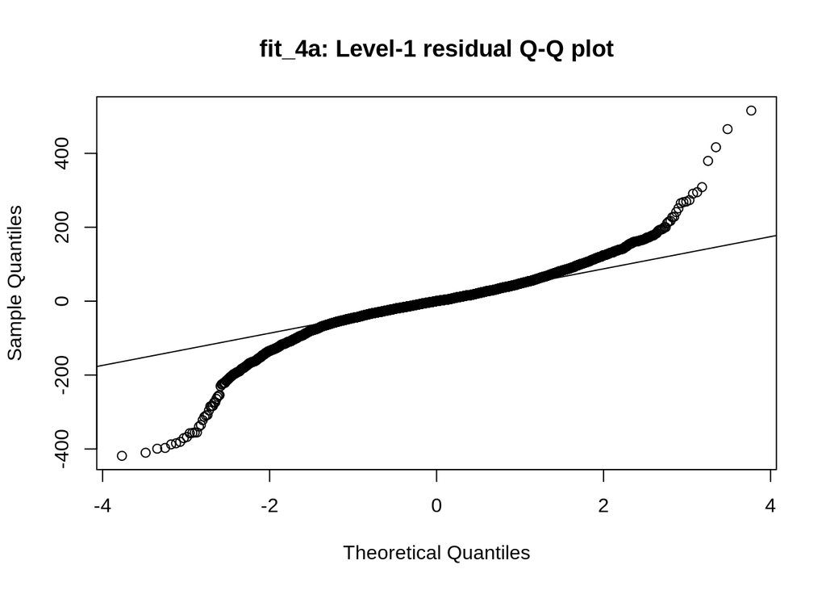

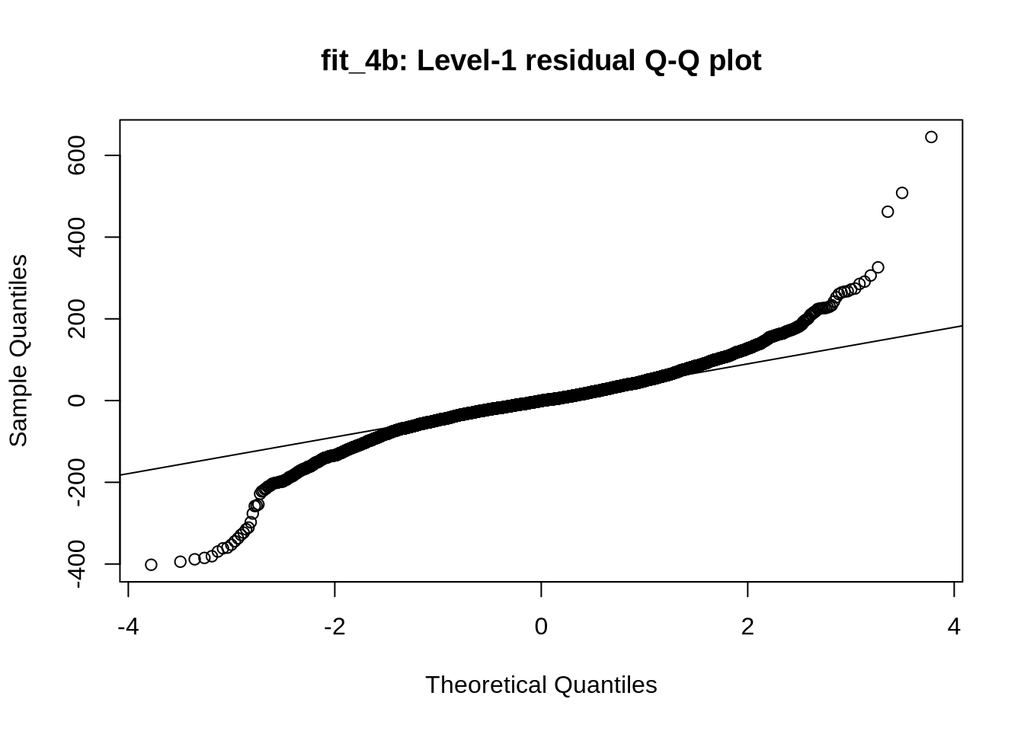